# Advanced Programming

Árpád Tamási · ELTE Faculty of Social Sciences

Session 5 — 6 October 2026

# Would you notice?

## Today’s session

|  | Min | What |
| --- | --- | --- |
| A | 20 | 25 days of parking |
| B | 20 | You had one job · 28 of 28 |
| C | 25 | Your spike |
| D | 15 | Homework 5 |

# 25 days of parking

## What do you pay?

```python
DAILY = 1000      # Ft
MONTHLY = 20000   # Ft, any 30 days in a row

def best_price(days):
```

You park for **25 days**. What do you pay?

## 25 days: two ways to pay

#### Daily tickets

25 × 1,000

**25,000 Ft**

#### Monthly pass

1 pass = any 30 days in a row

**20,000 Ft**

## Two tests, one program

```python
def best_price(days):
    return days * DAILY                # the code: forgets the pass

def test_by_the_agent():
    assert best_price(25) == 25000     # copied from running the code

def test_by_the_room():
    assert best_price(25) == 20000     # said before running
```

**The agent’s test passes** — it copied the code. **The room’s test fails** — and now you know the code is wrong.

## And 45 days?

The obvious fix:

```python
def best_price(days):
    return min(days * DAILY, MONTHLY)
```

Your 25-day test is now green. **What do you pay for 45 days?**

## 45 days: the room’s answer

1 pass (30 days) + 15 daily tickets = **35,000 Ft**. The fix said **20,000**.

```python
def test_45_days():
    assert best_price(45) == 35000     # said before running

def best_price(days):
    passes, rest = divmod(days, 30)
    return passes * MONTHLY + min(rest * DAILY, MONTHLY)
```

Two answers from outside caught two bugs. Now both tests are green.

# You had one job

## Mars Climate Orbiter, 1999

**What happened.** One team’s software sent thruster data in **pound-force seconds**. The navigation software expected **newton seconds**. Every number was off by a factor of 4.45.

**Why nobody noticed.** Each program was right by its own rules. The data flowed for months; small course errors were noticed, but nobody checked them against an outside number.

**The outside answer.** Where the spacecraft actually was. It flew too low and was lost. A $327 million mission.

Source: NASA Mars Climate Orbiter Mishap Investigation Board, Phase I Report, 10 Nov 1999.

## Budapest, Nyugati tér, 1980

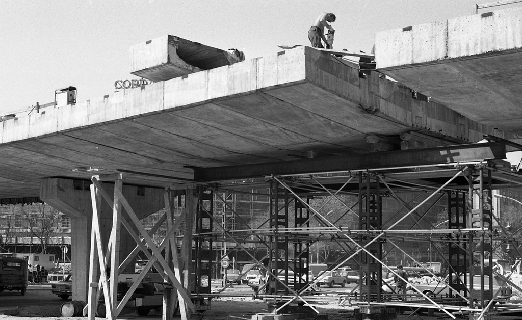

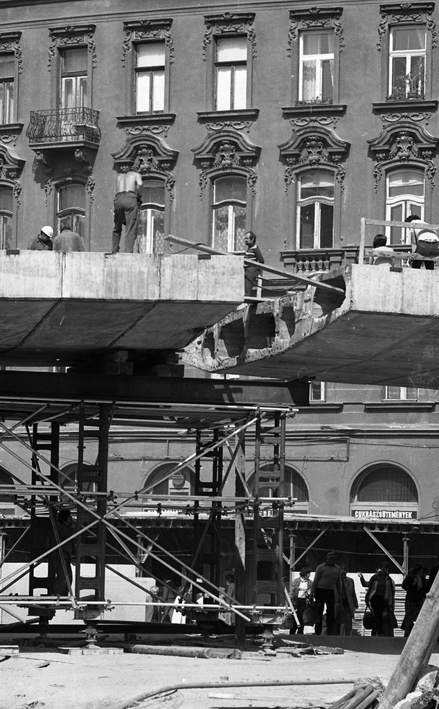

Built from both ends. In the middle, **the two halves did not meet** in height.

**The legend:** two different sea levels.

**The record:** the work was rushed — the elements were tensioned before the glue had set. Each half looked fine on its own.

Photos: Fortepan / Magyar Rendőr, 66589 and 66588 (CC BY-SA 3.0). Sources: retrolegends.hu, 2013; urbanlegends.hu, 2008.

## Laufenburg, 2003

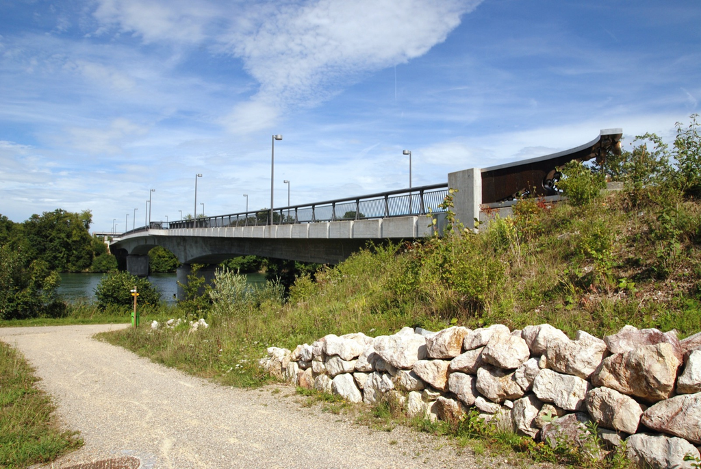

A bridge over the Rhine, Germany to Switzerland, built from both banks.

Germany measures height from the **North Sea**, Switzerland from the **Mediterranean**: 27 cm apart.

The gap: **54 cm**. Caught on site, December 2003.

Photo: Taxiarchos228, Wikimedia Commons (CC BY-SA 3.0). Sources: Kanton Aargau press release; swissinfo.ch, “Meereshöhe ist nicht gleich Meereshöhe”.

## You had one job

[figure not shown]

A good door. Good steps.

# 28 of 28

## Would your tests notice?

Your agents wrote **20,000 lines of tests**. They all pass.

We changed **one line** in each project, so that its main README promise became false. Then we ran your tests.

**28 of 28**: nothing went red.

Not a verdict on you. All 28 miss the same thing as the parking code: **a link to the real world.**

## Your program agrees with itself

## You have one job

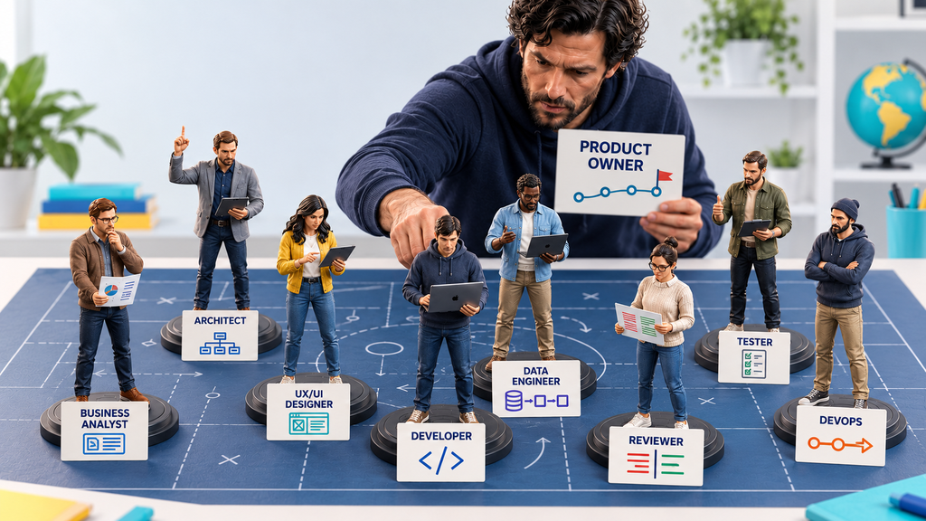

# Your spike

## Your spike

In Homework 4 you already measured your program against something real.

1. Find your project on the next slides.
2. Finish the sentence: *A test would go red if …*

That sentence is where Homework 5 starts.

## AlterEgo Finder

**What it does.** Give it a face photo; it shows the three most similar faces in a collection and how sure it is.

**What you found in Homework 4.** With 500 faces in the collection, 99 of 100 strangers got a match it called very sure.

**So right now:** in a large collection, “very sure” does not mean the person is there.

*A test would go red if …*

## Blocky

**What it does.** It blocks distracting websites on a weekly schedule; if you open one anyway, you get a page with better things to do.

**What you found in Homework 4.** Of ten sites chosen in advance, one (YouTube) still got through in your usual browser; you then changed the extension to step in earlier.

**So right now:** nobody has checked that the browser and the app together really show the “blocked” page.

*A test would go red if …*

## Budget Planner

**What it does.** You enter your income; it suggests a budget in six categories and warns when you overspend.

**What you found in Homework 4.** Sorting a real month of your own spending, about a quarter of the money fell under “other”.

**So right now:** a small month fits; a full month with cash is untried.

*A test would go red if …*

## CAUSAL LAB

**What it does.** You give it data on a treated and an untreated group; it plots both, says whether they moved alike beforehand, and estimates the treatment’s effect.

**What you found in Homework 4.** On simulated data with nothing wrong in it, the app’s trust score averaged 57.6 out of 100, because several checks warn for nothing.

**So right now:** a low score does not yet tell users whether their data really has a problem.

*A test would go red if …*

## Central European air traffic

**What it does.** It records planes over Central Europe on a schedule, so traffic over time can be asked about later.

**What you found in Homework 4.** You counted the fully captured hours over two weeks: only 23 of 337.

**So right now:** Answers about traffic over time would rest on data that is mostly gaps.

*A test would go red if …*

## ChatGPT Ads Industry Dashboard

**What it does.** It groups ChatGPT ad accounts by industry and compares their spending, clicks and sales between industries.

**What you found in Homework 4.** The gap between industries looked bigger than the one real campaign’s week-to-week swing: 143% versus 56%. But only one industry has real data; the others are example figures.

**So right now:** the industry differences on the chart are not yet real.

*A test would go red if …*

## Data Jobs & Skill-Gap Finder for Early-Career Professionals

**What it does.** For newcomers: from European data job ads, it shows which skills each data job asks for most.

**What you found in Homework 4.** You checked its skills against your own reading of 50 ads: right almost 99 times in 100.

**So right now:** an ad that says “R&D” could be counted as asking for the skill “R”, and nothing would notice.

*A test would go red if …*

## deriva

**What it does.** It compares two rounds of a labour survey and reports what changed, keeping real changes apart from cosmetic ones.

**What you found in Homework 4.** You tried three rounds it had never seen: 3 of 3 loaded unchanged.

**So right now:** it reads new rounds, but still calls many cosmetic changes real.

*A test would go red if …*

## Detective game with LLM-driven NPCs

**What it does.** A murder mystery: you question three suspects played by an AI, then name the killer.

**What you found in Homework 4.** In 30 real conversations, every reply passed the game’s check that suspects stick to what they know.

**So right now:** the short intro the AI adds before an answer is not checked, so a secret could slip out there.

*A test would go red if …*

## European bank financial data loader

**What it does.** Pick a European bank and year; it gathers its key figures from two public sources into one table.

**What you found in Homework 4.** Checked against the bank’s own reports, the figures agree, and its risk ratio comes out at 44.5%.

**So right now:** right for one bank and one year; others are unchecked.

*A test would go red if …*

## Explainable Fraud Detection

**What it does.** It reads a list of card payments and picks the ones worth a closer look, saying why.

**What you found in Homework 4.** On a public dataset where fraud is already marked, 68 of its 500 picks were really fraud.

**So right now:** most of the short list is not fraud.

*A test would go red if …*

## Financial Planner

**What it does.** From your bank statements, it shows where your money went, by category, month by month and over the year.

**What you found in Homework 4.** You sorted a fresh month by hand: shops it knew were almost always right, new shops only about two in three.

**So right now:** spending at unfamiliar shops often lands in the wrong category.

*A test would go red if …*

## Market Research Platform

**What it does.** Load the results of a survey; it builds a report by research goal and names the top answers to each question, with percentages.

**What you found in Homework 4.** Can the summary file tell you what one age group answered? No — that number could be anything from zero to the whole group.

**So right now:** nothing checks that the report names the right top answer with the right percentage.

*A test would go red if …*

## MarketLens

**What it does.** Beginners practise investing with play money: it says whether stocks, bonds or gold will rise or fall, explains why, and tracks the portfolio at real prices.

**What you found in Homework 4.** Replaying past days, its forecasts were right slightly less often than a rule that always says “up”: 52 versus 55 in 100.

**So right now:** nobody has checked that an old forecast is scored against the right day’s price.

*A test would go red if …*

## Menstrual Cycle Phase Calculator and Targeted Nutrition Planner

**What it does.** From your last period and cycle length, it tells you your cycle phase, which nutrients to focus on, and writes a grocery list.

**What you found in Homework 4.** You looked for medical sources behind its advice: 7 of 12 pairings have one, but mostly for the whole cycle, not one phase.

**So right now:** users are not told how strong the evidence behind each suggestion is.

*A test would go red if …*

## Ms. Match

**What it does.** You photograph your own clothes; it reads today’s forecast, and one click puts together an outfit shown on a photo of you.

**What you found in Homework 4.** Adding ten of your own photos, you measured that the browser holds about 63 of your own garments, close to the original guess.

**So right now:** on a rainy day the outfit button ignores the weather, so it may still pick trainers or high heels.

*A test would go red if …*

## Photo Duplicate Finder

**What it does.** It finds copies and near-identical shots in a photo folder and suggests which to keep. It never deletes anything.

**What you found in Homework 4.** On about 300 of your own photos, only the strictest settings kept groups clean; the default chained unrelated photos together.

**So right now:** nobody knows yet whether today’s setting keeps bursts together and merely similar shots apart.

*A test would go red if …*

## PixWars

**What it does.** A team game over a local network: build bridges between floating platforms and break the other team’s bed.

**What you found in Homework 4.** On your home wifi, between a laptop and a phone, no game messages were lost, but the slowest ones were too slow for smooth play.

**So right now:** nobody knows yet whether two laptops can play on the classroom wifi.

*A test would go red if …*

## plant_care

**What it does.** Each houseplant gets a card that counts down to its next watering.

**What you found in Homework 4.** You looked up 12 plants with a gardening society: none gives a number of days, only soil dryness or season.

**So right now:** The countdown is a starting guess, and the app now says so.

*A test would go red if …*

## Process Swimlane Generator

**What it does.** From a table describing a workplace process, it draws a diagram: a lane per department, a box per task, arrows for the order.

**What you found in Homework 4.** On five real, anonymised processes, four worked; one failed because it really has a yes-or-no branch.

**So right now:** nobody has checked that long processes stay readable, or that each arrow lands on the next task.

*A test would go red if …*

## RC Atlas

**What it does.** A programme manager, a field coordinator and a monitoring officer pass tasks along: assign, do, submit, check, approve, and the project status follows.

**What you found in Homework 4.** On a fresh install, a fixed ten-step workflow saved every step: 10 of 10.

**So right now:** nobody has checked that each person sees only the buttons meant for their role.

*A test would go red if …*

## RepoScout

**What it does.** Type a topic; it ranks GitHub projects and says how alive the field is.

**What you found in Homework 4.** You compared GitHub’s “last updated” date with each project’s real last change: 5 of 50 landed in the wrong group.

**So right now:** A few projects it calls active may not really have changed lately.

*A test would go red if …*

## Route Tariff and Capacity Fee Calculator

**What it does.** A gas trader picks a pipeline point and period and gets the cheapest way to book capacity.

**What you found in Homework 4.** Booking a little more time than needed was cheaper in four of ten realistic cases.

**So right now:** it now books extra time, but never considers a whole-year booking.

*A test would go red if …*

## sentmine

**What it does.** From an English text you just read, it makes a flashcard for each new word, in its real sentence.

**What you found in Homework 4.** You checked every card from one newspaper article by hand: 4 of 103 were really new words.

**So right now:** Most cards are known words or names, so the learner still sorts them by hand.

*A test would go red if …*

## Stardew Valley Auto-Gifter

**What it does.** A Stardew Valley add-on: it plans tomorrow’s gifts for villagers from a chest, you approve the plan, and it hands them over as you walk past.

**What you found in Homework 4.** The specially marked chest kept its colour at all 3 openings, also after saving and reloading.

**So right now:** a villager who already got a gift today may still get another one.

*A test would go red if …*

## SurveyGuard: Numeric Careless Responding Detector

**What it does.** It marks survey respondents who seem to answer carelessly, for example the same answer everywhere, and says why.

**What you found in Homework 4.** On real public survey data, one of its checks, at the old setting, flagged about 7 in 10 ordinary respondents.

**So right now:** someone who gives the same answer to every question is not marked suspicious.

*A test would go red if …*

## Toto Estimator

**What it does.** Enter this week’s Toto matches; it tips home win, draw or away win from past results.

**What you found in Homework 4.** On a real English season it had not seen: 40% right, against 46% for always tipping a home win.

**So right now:** Always tipping a home win currently scores better than its tips.

*A test would go red if …*

## Volleyball Statistics Tracker

**What it does.** It turns European volleyball match reports into team and player summaries.

**What you found in Homework 4.** You compared its team totals with the federation’s own sheet: 22 of 24 matched exactly, the rest only by rounding.

**So right now:** Correct today, but only a small hand-made sample is checked, not a real full report.

*A test would go red if …*

## Homework 5 — Make it usable

- Finish your sentence — *A test would go red if …* — and write that test. **You** give the expected value, from outside the program.
- Show it **red** (break one line), then **green**.
- Use your program **once for real**: expected before, got after — in the log.
- Branch `hw5-usable`, pull request, merge commit — as before.